# IE 582 - Homework 3

Yusuf Burak Ovali

11/19/2018

## Task 1 - Nearest-Neighbor Classifier

### Objective

The objective of the project is to apply nearest-neighbor classifiers with two alternative distance measures to find the labels of test instances based on acceleration information of 8 gestures .

### Task 1-a

- Reading the data and visualize one instance with all axes from each class and trying to relate the shape (time series) with the gesture shown in Figure 1. Note that this is an acceleration information.

Data is read from dms file, converted to a matrix and stored as a separate parameter for each axis.

```r
fname_xtrain='Desktop/uWaveGestureLibrary_X_TRAIN.dms'
fname_ytrain='Desktop/uWaveGestureLibrary_Y_TRAIN.dms'
fname_ztrain='Desktop/uWaveGestureLibrary_Z_TRAIN.dms'
traindatax <- as.matrix(read.table(fname_xtrain))
traindatay <- as.matrix(read.table(fname_ytrain))
traindataz <- as.matrix(read.table(fname_ztrain))
```

Since there is a need for a 3D plot representation of an instance from each class, the traindatax is printed and particular instances are chosen as follows:

```r
trainxclass=traindatax[,1]
```

```r
trainxclass[1:15]
```

```
##  [1] 6 5 5 3 4 8 7 4 4 6 1 7 3 5 2
```

1st Class -> Instance 11

2nd Class -> Instance 15

3rd Class -> Instance 4

4th Class -> Instance 5

5th Class -> Instance 2

6th Class -> Instance 1

7th Class -> Instance 7

8th Class -> Instance 6

Since each class will be represented on a different chart and instance numbers are taken, there is no need for keeping class information anymore

```r
traindatax=traindatax[,2:ncol(traindatax)]
traindatay=traindatay[,2:ncol(traindatay)]
traindataz=traindataz[,2:ncol(traindataz)]
```

To draw a 3D scatter plot for the 1st Class, the values of the instance 11 is taken as vector.

```r
f1_xvec = traindatax[11,]
f1_yvec = traindatay[11,]
f1_zvec = traindataz[11,]
```

The acceleration information is transformed to velocity information by computing the cumulative sum of acceleration over time to get better insights.

```r
f1_xvec = cumsum(f1_xvec)
f1_yvec = cumsum(f1_yvec)
f1_zvec = cumsum(f1_zvec)
```

“plotly” and “data.table” packages are recalled to preprocess the data and illustre it in 3D.

```r
library(plotly)
library(data.table)
```

Different vectors are merged into one single data table.

```r
data_f1 = list(
  x = f1_xvec,
  y = f1_yvec,
  z = f1_zvec
)
dt_f1 = as.data.table(data_f1)
```

Velocity in the three axis over a time period is illustrated by using plot_ly function. Since there is no difference in the code structure of different classes, detailed code lines are omitted for other figure classes.

**1st class:**

[interactive chart not shown]

As it can be seen from the plot above, there is a increase in the velocity on the x axis for a while, how ever the velocity reaches to 0 at the middle and goes to negative until it hits to 0 again. Moreover, the velocity on the Y axis is always negative. If we combine these two findings, it can be concluded that this plot represented the Figure 1 since its direction on the x axis changes from positive to negative and its direction on the y axis is always downward.

**2nd class:**

[interactive chart not shown]

In the second chart, the pattern is again consistent with the figure 2 since there are opposite directions in the all axes. There are both increases and decreases in all axes.

**3rd class:**

[interactive chart not shown]

**4th class:**

[interactive chart not shown]

3rd and 4th figures should be considered together since their shape is mainly the same except the direction. It is expected to observe opposite velocities on the particular axes.The main opposition is on the x axis which is strictly negative in the Figure 3, where as it is mainly on the positive side in the Figure 4.

**5th class:**

[interactive chart not shown]

**6th class:**

[interactive chart not shown]

Same procedure can be applied to Figure 5 and Figure 6 as well since they are also similar except the direction. Opposite values on the Y and Z axes are observed and their magnitudes are almost same for the both figures. What is interesting here is the difference on the X axis. In the 5th Figure the velocity on the X axis is biased towards positive values, however its mean in the 6th Figure is around 0. From that, we can understand that, the users are better at drawing a straight line on the X axis for the 6th figure. It is also obvious that the variance in the velocity on the X axis for Figure 5 is larger than the one for the Figure 6.

**7th class:**

[interactive chart not shown]

**8th class:**

[interactive chart not shown]

These two charts are almost the same because of the continuity of the pattern in the Figure 7 and Figure 8. They are both circular with different directions. However the resulting circular shape is the same only the ways they are created are different.

### Task 1-b

In this part, nearest-neighbor classification is applied to the test instances for the figures. Two different distance measure alternatives are offered as Euclidean and Manhattan. For each distance measure alternative, the training data is used to identify the optimal value of k which minimizes the error of a 10-fold cross-validation.

The data is read through read.table function and kept into different matrices for each axis.

```r
fname_xtrain='Desktop/uWaveGestureLibrary_X_TRAIN.dms'
fname_ytrain='Desktop/uWaveGestureLibrary_Y_TRAIN.dms'
fname_ztrain='Desktop/uWaveGestureLibrary_Z_TRAIN.dms'
traindatax <- as.matrix(read.table(fname_xtrain))
traindatay <- as.matrix(read.table(fname_ytrain))
traindataz <- as.matrix(read.table(fname_ztrain))
```

Since the different matrices will be merged, their column names are changed accordingly to avoid any confusion that may occur during the computation.

```r
colnames(traindatax) = paste ("X", colnames(traindatax), sep = "_")
colnames(traindatay) = paste ("Y", colnames(traindatay), sep = "_")
colnames(traindataz) = paste ("Z", colnames(traindataz), sep = "_")
```

The class information in the y-axis and z-axis matrices is deleted since they will not be used after the mergence. After that, all matrices are combined with cbind function

```r
traindatay=traindatay[,2:ncol(traindatay)]
traindataz=traindataz[,2:ncol(traindataz)]
traindata=cbind(traindatax,traindatay,traindataz)
```

The class information is tranformed to factor because it is going to be target value for classification.

```r
traindata[,1] =factor(traindata[,1])
```

While choosing k for the nearest neighbor classification, usually it is set to square root of the total number of observations as a thumb rule. However, we will perform a statistics to find the best k.

“train” function in the “Caret” package will be used.

```r
library(caret)
```

As a preliminary adjustment, method is set to repeated cross validation with 3 repeats and 10 folds.

```r
ctrl <- trainControl(method="repeatedcv",repeats = 3, number = 10)
```

For the euclidean distance, scaling is performed to avoid putting any weight to specific features.

```r
euc_knn <- train(X_V1 ~., data = traindata , method = "knn", trControl = ctrl,preProcess = c("center", "scale"),
                 tuneLength = 10)
```

As it can be seen below, k = 5 gives the least RMSE in terms of 10-fold cross-validation. So, 5 nearest neighbors should be considered while predicting the labels of test instances by using euclidean distance.

```r
euc_knn
```

```
## k-Nearest Neighbors
##
## 896 samples
## 945 predictors
##
## Pre-processing: centered (945), scaled (945)
## Resampling: Cross-Validated (10 fold, repeated 3 times)
## Summary of sample sizes: 806, 806, 806, 807, 807, 806, ...
## Resampling results across tuning parameters:
##
##   k   RMSE       Rsquared   MAE
##    5  0.6039459  0.9269278  0.2073530
##    7  0.6432714  0.9173528  0.2406943
##    9  0.6673985  0.9118879  0.2649175
##   11  0.6914187  0.9052943  0.2929333
##   13  0.7261363  0.8960391  0.3185863
##   15  0.7559282  0.8875215  0.3412476
##   17  0.7811350  0.8803849  0.3625906
##   19  0.8074859  0.8725290  0.3860202
##   21  0.8262958  0.8670962  0.4075599
##   23  0.8418064  0.8626552  0.4264799
##
## RMSE was used to select the optimal model using the smallest value.
## The final value used for the model was k = 5.
```

For the manhattan distance, same procedure is applied, but instead of “knn” method “kknn” method is used since it gives more flexibility in terms of the degree of distance which can be set as 1 for the manhattan distance. For that purpose, “kknn” package is recalled.

```r
library(kknn)

man_knn =train(X_V1 ~.,data = traindata ,method = "kknn",trControl = ctrl, preProcess = c("center", "scale"),
              tuneLength = 10,tuneGrid = expand.grid(kmax=c(1:10),distance=1,kernel="optimal") )
```

```r
man_knn
```

```
## k-Nearest Neighbors
##
## 896 samples
## 945 predictors
##
## Pre-processing: centered (945), scaled (945)
## Resampling: Cross-Validated (10 fold, repeated 3 times)
## Summary of sample sizes: 806, 806, 807, 806, 807, 806, ...
## Resampling results across tuning parameters:
##
##   kmax  RMSE       Rsquared   MAE
##    1    0.4841591  0.9451109  0.09814092
##    2    0.4722764  0.9485635  0.11088590
##    3    0.4773881  0.9485573  0.11802172
##    4    0.4795168  0.9486845  0.12138568
##    5    0.4794581  0.9489552  0.12226618
##    6    0.4802213  0.9489543  0.12299195
##    7    0.4801856  0.9489587  0.12319078
##    8    0.4801856  0.9489587  0.12319078
##    9    0.4801856  0.9489587  0.12319078
##   10    0.4801856  0.9489587  0.12319078
##
## Tuning parameter 'distance' was held constant at a value of 1
##
## Tuning parameter 'kernel' was held constant at a value of optimal
## RMSE was used to select the optimal model using the smallest value.
## The final values used for the model were kmax = 2, distance = 1 and
##  kernel = optimal.
```

Based on the results, unlike the euclidean distance, in the manhattan distance, the optimal k value that minimizes the error of 10-fold cross-validation is 2. So for the prediction of the labels of test instances, 2 nearest neighbors will be considered.

### Task 1-c

The objective of this task is to use the k-value coming from previous part and evaluate final performance on the test data and present results in a confusion matrix showing the counts for actual and predicted labels. In addition, quoting the runtime and accuracy for the results is needed.

Same procedure is applied to the test data in order to work on the test and the training data together.

```r
fname_xtest='Desktop/uWaveGestureLibrary_X_TEST.dms'
fname_ytest='Desktop/uWaveGestureLibrary_Y_TEST.dms'
fname_ztest='Desktop/uWaveGestureLibrary_Z_TEST.dms'
testdatax <- as.matrix(read.table(fname_xtest))
testdatay <- as.matrix(read.table(fname_ytest))
testdataz <- as.matrix(read.table(fname_ztest))

colnames(testdatax) = paste ("X", colnames(testdatax), sep = "_")
colnames(testdatay) = paste ("Y", colnames(testdatay), sep = "_")
colnames(testdataz) = paste ("Z", colnames(testdataz), sep = "_")

testdatay=testdatay[,2:ncol(testdatay)]
testdataz=testdataz[,2:ncol(testdataz)]
testdata=cbind(testdatax,testdatay,testdataz)
testdata[,1]=as.vector(testdata[,1])
```

“e1071”, “caret”, “class” and “data.table” packages are recalled to preprocess the data and perform the prediction.

```r
library(e1071)
library(caret)
library(class)
library(data.table)
```

For the prediction by using euclidean distance, 5 nearest neighbors classification is applied with knn function and the results are kept as euc_prediction. “traindataclass” is the vector of train data classes.

```r
traindataclass=traindata[,1]
euc_prediction = knn(train = traindata,test = testdata, cl = traindataclass, k = 5 )
```

For the prediction by using manhattan distance, 2 nearest neighbors are considered and kknn function is recalled. Distance parameter is given as 1 to indicate it is manhattan. However, because of the structure of kknn function, before using kknn function, the test and train datasets are converted to data table.

```r
traindata_man=as.data.table(traindata)
testdata_man = as.data.table(testdata)
testdataclass=testdata[,1]
man_prediction = kknn(formula = X_V1 ~.,traindata_man, testdata_man, k = 2,distance = 1 )
```

To evaluate and compare the performances of predictions, 8-by-8 confusion matrices are constructed for both of the classification methods.

For the euclidean distance:

```r
factor_euc = factor(euc_prediction)
factor_actual = factor (testdataclass)
confmatrix_euc=confusionMatrix(factor_euc,factor_actual)
```

```r
confmatrix_euc
```

```
## Confusion Matrix and Statistics
##
##           Reference
## Prediction   1   2   3   4   5   6   7   8
##          1 428   1   0   3   3   4   0   0
##          2   0 449   0   0   0   0   0   0
##          3   0   0 405   0   5   5   3   0
##          4   3   0   1 369   1  16   0   1
##          5   0   0  21  64 423  32   0   1
##          6   6   0  21   8   1 392   0   0
##          7   0   2   6   0   0   0 444   0
##          8   0   0   0   6   0   0   0 458
##
## Overall Statistics
##
##                Accuracy : 0.9403
##                  95% CI : (0.932, 0.9478)
##     No Information Rate : 0.1284
##     P-Value [Acc > NIR] : < 2.2e-16
##
##                   Kappa : 0.9317
##  Mcnemar's Test P-Value : NA
##
## Statistics by Class:
##
##                      Class: 1 Class: 2 Class: 3 Class: 4 Class: 5 Class: 6
## Sensitivity            0.9794   0.9934   0.8921   0.8200   0.9769   0.8731
## Specificity            0.9965   1.0000   0.9958   0.9930   0.9625   0.9885
## Pos Pred Value         0.9749   1.0000   0.9689   0.9437   0.7819   0.9159
## Neg Pred Value         0.9971   0.9990   0.9845   0.9746   0.9967   0.9819
## Prevalence             0.1220   0.1262   0.1267   0.1256   0.1209   0.1253
## Detection Rate         0.1195   0.1253   0.1131   0.1030   0.1181   0.1094
## Detection Prevalence   0.1226   0.1253   0.1167   0.1092   0.1510   0.1195
## Balanced Accuracy      0.9880   0.9967   0.9440   0.9065   0.9697   0.9308
##                      Class: 7 Class: 8
## Sensitivity            0.9933   0.9957
## Specificity            0.9974   0.9981
## Pos Pred Value         0.9823   0.9871
## Neg Pred Value         0.9990   0.9994
## Prevalence             0.1248   0.1284
## Detection Rate         0.1240   0.1279
## Detection Prevalence   0.1262   0.1295
## Balanced Accuracy      0.9954   0.9969
```

Computation time is also calcuted by logging the start time and end time as follows:

```r
start.time <- Sys.time()
euc_prediction = knn(train = traindata,test = testdata, cl = traindataclass, k = 5 )
euc_prediction
end.time <- Sys.time()
time.taken_euc_predict<- end.time - start.time
```

```r
time.taken_euc_predict
```

```
## Time difference of 27.1843 secs
```

The computation time is 27.18 seconds.

For the manhattan distance, since the output is a list with multiple items, predicted values are extracted in additional 2 steps:

```r
man_scores = man_prediction[["CL"]]
man_scores = man_scores[,1]
factor_man = factor(man_scores)
factor_actual = factor (testdataclass)
confmatrix_man=confusionMatrix(factor_man,factor_actual)
```

```r
confmatrix_man
```

```
## Confusion Matrix and Statistics
##
##           Reference
## Prediction   1   2   3   4   5   6   7   8
##          1 432   1   2   3   3   3   0   0
##          2   0 451   0   0   0   0   0   0
##          3   0   0 417   0   9   6   3   0
##          4   1   0   0 395   4  12   0   3
##          5   0   0  16  41 416  15   0   1
##          6   4   0  14   8   1 412   0   0
##          7   0   0   5   0   0   0 444   0
##          8   0   0   0   3   0   1   0 456
##
## Overall Statistics
##
##                Accuracy : 0.9556
##                  95% CI : (0.9483, 0.9621)
##     No Information Rate : 0.1284
##     P-Value [Acc > NIR] : < 2.2e-16
##
##                   Kappa : 0.9493
##  Mcnemar's Test P-Value : NA
##
## Statistics by Class:
##
##                      Class: 1 Class: 2 Class: 3 Class: 4 Class: 5 Class: 6
## Sensitivity            0.9886   0.9978   0.9185   0.8778   0.9607   0.9176
## Specificity            0.9962   1.0000   0.9942   0.9936   0.9768   0.9914
## Pos Pred Value         0.9730   1.0000   0.9586   0.9518   0.8507   0.9385
## Neg Pred Value         0.9984   0.9997   0.9882   0.9826   0.9945   0.9882
## Prevalence             0.1220   0.1262   0.1267   0.1256   0.1209   0.1253
## Detection Rate         0.1206   0.1259   0.1164   0.1103   0.1161   0.1150
## Detection Prevalence   0.1240   0.1259   0.1214   0.1159   0.1365   0.1226
## Balanced Accuracy      0.9924   0.9989   0.9564   0.9357   0.9688   0.9545
##                      Class: 7 Class: 8
## Sensitivity            0.9933   0.9913
## Specificity            0.9984   0.9987
## Pos Pred Value         0.9889   0.9913
## Neg Pred Value         0.9990   0.9987
## Prevalence             0.1248   0.1284
## Detection Rate         0.1240   0.1273
## Detection Prevalence   0.1253   0.1284
## Balanced Accuracy      0.9958   0.9950
```

```r
time.taken_man_predict
```

```
## Time difference of 1.182968 mins
```

However, in terms of the classification accuracy, 2 nearest-neighbor with manhattan distance is slightly better choice.

## Task 2 - Lasso Penalized Regression

### Objective

1. Train a logistic regression model on the ECG training data using fused lasso penalties. Use the learned model to predict the class for test data.
2. Comment on the regression coefficients.
3. Suppose you take the difference between consecutive time series observations to transform the time series. Let 𝑥𝑡 be the observation at time point t and you are asked to create a new time series which is 𝑦𝑡=𝑥𝑡−𝑥𝑡−1 for 𝑡=2,3,…,𝑇 where T is the length of the time series. Perform the same operation in part (a) for this newly created dataset and compare the results
4. Comment on the regression coefficients for the model trained on the new dataset.

As an initialization, training and test data of ECG information are read.

```r
fname_ECGtrain='Desktop/ecgTRAIN.dms'
fname_ECGtest='Desktop/ecgTEST.dms'
traindata <- as.matrix(read.table(fname_ECGtrain))
testdata <- as.matrix(read.table(fname_ECGtest))
```

Classes of training data is kept as a vector. Since logistic regression works for binary variables, classes are -1 and 1 are converted to 0 and 1. After performing necessary operations

```r
trainclass=traindata[,1]
trainclass[trainclass==-1]=0
traindata=traindata[,2:ncol(traindata)]
testclass=testdata[,1]
testclass[testclass==-1]=0
testdata=testdata[,2:ncol(testdata)]
```

### Task 2-a

To train logistic regression using the lasso penalties, “lqa” and “penalized” packages are used

```r
library(lqa)
library(penalized)
```

Firstly, there is a need for calculating the possible lambdas than can be used in the logistic regression for fused lasso penalization. The larger lambdas mean there is going to be more penalty. To calculate lambda candidates, “profL1” function in the “penalized” package is used. As a min value for lambda1, 0.5 is set. While learning the parameters of fused lasso, 10-fold cross validation is applied within the profL1 function.

```r
cv_lambd_2 = profL1(response = trainclass, penalized = traindata, fusedl = TRUE, model = "logistic", standardize = TRUE, fold = 10,minlambda1 = 0.5)
```

Lambda candidate lists are assigned to “lambda2” parameter. Since the main objective is to apply fused lasso penalty, lambda1 value is set as 1 and lambda2 values are included as list.

```r
lambda2=cv_lambd_2$lambda
lambdas=list(1,lambda2)
```

Logistic regression model is constructed with “cv.lqa”" function in the “lqa” package. Since logistic regression is used for the binary classification, as a family parameter binomial() is given.

```r
cvFused=cv.lqa(trainclass,traindata,lambda.candidates = lambdas, intercept = FALSE,
               family=binomial(), penalty.family=fused.lasso,n.fold=10,loss.func ="aic.loss")
```

In order to make predictions with logistic regression model, first there is a need for transforming testdata to data table format.

```r
testdata_table=as.data.table(testdata)
```

To make predictions for the test data, “predict.lqa” in “lqa” package is recalled.

```r
predictions_ECG=predict.lqa(cvFused$best.obj, new.x = testdata_table)
```

Since the predicted classes are stored in the mu.new of the object, they are assigned to predicted_class. Moreover, the predictions are in the form of predictions since the model is logistic regression. So values greater than or equal to 0.5 should be assigned to class 1 and values less than 0.5 should be assigned to 0 (-1 in the real test data)

```r
predicted_class = predictions_ECG$mu.new
predicted_class[predicted_class>=0.5]=1
predicted_class[predicted_class<0.5]=0
```

The confusion matrix 2by2 is calculated with the ConfusionMatrix function.

```r
factor_ECG = factor(predicted_class)
factor_actual = factor (testclass)
confmatrix_ECG=confusionMatrix(factor_ECG,factor_actual)
```

The resulting values are:

```r
confmatrix_ECG
```

```
## Confusion Matrix and Statistics
##
##           Reference
## Prediction  0  1
##          0 18  2
##          1 18 62
##
##                Accuracy : 0.8
##                  95% CI : (0.7082, 0.8733)
##     No Information Rate : 0.64
##     P-Value [Acc > NIR] : 0.0003862
##
##                   Kappa : 0.5192
##  Mcnemar's Test P-Value : 0.0007962
##
##             Sensitivity : 0.5000
##             Specificity : 0.9688
##          Pos Pred Value : 0.9000
##          Neg Pred Value : 0.7750
##              Prevalence : 0.3600
##          Detection Rate : 0.1800
##    Detection Prevalence : 0.2000
##       Balanced Accuracy : 0.7344
##
##        'Positive' Class : 0
##
```

As it can be seen from the results, the accuracy is 80% which is not bad. The 95% confidence interval is between (0.7 and 0.87). The model is better at predicting the class 1 instead of class 0 which is -1 in the real data.

### Task 2-b

In order to comment on regression coefficients, we can plot these coefficients to understand better.

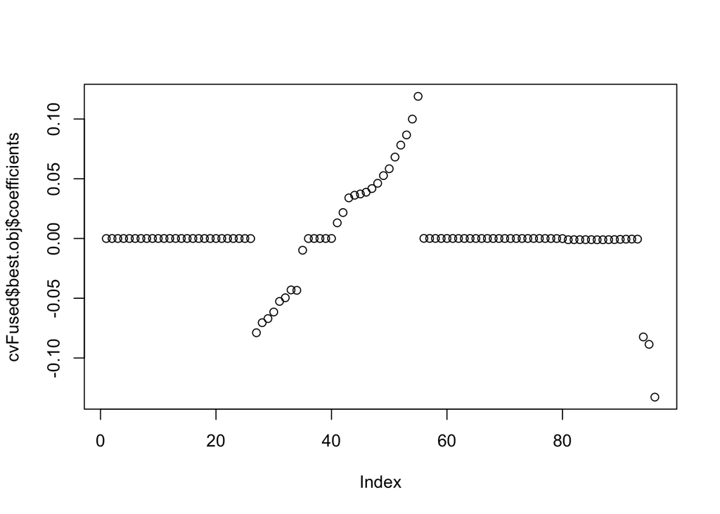

```r
plot(cvFused$best.obj$coefficients)
```

On the x axis the variables are shown and on the y axis the corresponding coefficients are provided. What we see here is, most of the variables have zero coefficients which means they do not have significant improtance. Especially variables between 25 to 35 have negative impact whereas variables between 45 to around 55 have positive impacts on the model. From 25 to 35 the impact is decreasing while between 45 to 55, the impact they have is increasing.

### Task 2-c

There is a need for transforming both training data and test data to time series by performing matrix operations.

For the train data, for loop is used and the column names are adjusted as follows:

```r
noftimeseries_ECG=nrow(traindata)
tlength_ECG=ncol(traindata)
old_matrix=as.matrix(traindata)
timeseries_train = as.matrix(traindata)
for(r in 1:noftimeseries_ECG) {
  for(c in 2:tlength_ECG){
    timeseries_train[r,c] = old_matrix[r,c]-old_matrix[r,c-1]
  }
}
timeseries_train = timeseries_train[,2:ncol(timeseries_train)]
colnames(timeseries_train)=as.character(c(2:96))
```

For the test data, for loop is used and the column names are adjusted as follows:

```r
noftimeseries_ECG_timeseries=nrow(testdata)
tlength_ECG_timeseries=ncol(testdata)

old_matrix_ts=as.matrix(testdata)
timeseries_test = as.matrix(testdata)
for(r in 1:noftimeseries_ECG_timeseries) {
  for(c in 2:tlength_ECG_timeseries){
    timeseries_test[r,c] = old_matrix_ts[r,c]-old_matrix_ts[r,c-1]
  }
}
timeseries_test = timeseries_test[,2:ncol(timeseries_test)]
colnames(timeseries_test)=as.character(c(2:96))
```

Same procedure is applied to both training data and test data as in the Task2-a part.

```r
v_lambd_2_ts = profL1(response = trainclass, penalized = timeseries_train, fusedl = TRUE, model = "logistic", standardize = TRUE, fold = 10,minlambda1 = 0.5)
cv_lambd_2_ts$lambda

lambda2_ts=cv_lambd_2_ts$lambda
lambdas_ts=list(1,lambda2_ts)
cvFused_ts=cv.lqa(trainclass,timeseries_train,lambda.candidates = lambdas_ts, intercept = FALSE,
               family=binomial(), penalty.family=fused.lasso,n.fold=10,loss.func = "aic.loss")
testdata_table_ts=as.data.table(timeseries_test)

predictions_ECG_ts=predict.lqa(cvFused_ts$best.obj, new.x = testdata_table_ts)
predicted_class_ts = predictions_ECG_ts$mu.new

predicted_class_ts[predicted_class_ts>=0.5]=1
predicted_class_ts[predicted_class_ts<0.5]=0
factor_ECG_ts = factor(predicted_class_ts)
factor_actual = factor (testclass)
confmatrix_ECG_ts=confusionMatrix(factor_ECG_ts,factor_actual)
```

Confusion matrix is calculated as:

```r
confmatrix_ECG_ts
```

```
## Confusion Matrix and Statistics
##
##           Reference
## Prediction  0  1
##          0 20  4
##          1 16 60
##
##                Accuracy : 0.8
##                  95% CI : (0.7082, 0.8733)
##     No Information Rate : 0.64
##     P-Value [Acc > NIR] : 0.0003862
##
##                   Kappa : 0.5318
##  Mcnemar's Test P-Value : 0.0139063
##
##             Sensitivity : 0.5556
##             Specificity : 0.9375
##          Pos Pred Value : 0.8333
##          Neg Pred Value : 0.7895
##              Prevalence : 0.3600
##          Detection Rate : 0.2000
##    Detection Prevalence : 0.2400
##       Balanced Accuracy : 0.7465
##
##        'Positive' Class : 0
##
```

The accuracy rate is 80% which is same as part a. What is interesting is, the trained logistic regression with time series becomes better at predicting 0’s (it was %50 in the part a ) whereas its performance has decreased for predicting the class 1. However, the total accuracy doesn’t change at all. The confidence intervals look similar in both case.

### Task 2-d

In order to comment on regression coefficients, we can plot these coefficients to understand better.

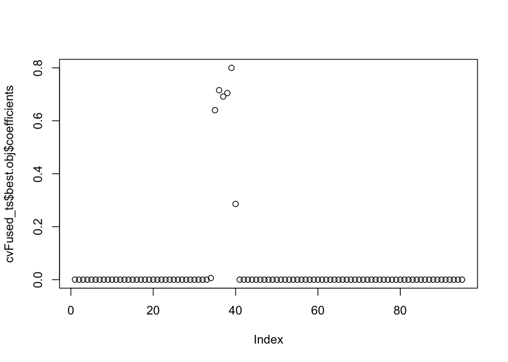

```r
plot(cvFused_ts$best.obj$coefficients)
```